# Relationship of Field Goal Percentage of NBA Players by Position and Games Played

Tony DiRubbo

## Phase 1. Project Proposal

### 1.0 Introduction

As a media management major and data analytics minor, I have found that media and data are almost everywhere. The sports industry is one where media is used to promote games, teams, and individuals. On the data side almost all professional sporting activities are numbers driven and various statistics can be recorded from a single minute of playing time. The National Basketball Association (NBA) itself is a sports league heavily rested in its statistics.

Websites such as basketball-reference.com provide a cornucopia of basketball related data which users can obtain starting from the founding years of the NBA. The link below leads to the player statistical totals for the last complete NBA Season (2020-2021), from there the data can be exported to CSV format.

https://www.basketball-reference.com/leagues/NBA_2021_totals.html

The data field contains the total statistics for every NBA player for the 2020-2021 NBA season. This includes variables ranging from points scored to minutes played. Each of the 540 players who played in the league during this season is an observational unit for this study, none of the players will be removed from the data field. The entire population of NBA players who played at least one game this season will be examined.

The response variable is going to be made field goal percentage (FG%). A field goal is any made basket while play is active, free throws are exempt, and an individual’s field goal percentage is the percent field goals made among the total field goals taken.

The research question being asked is if a player’s field goal percentage is possibly affected by the position of that player and/or the number of games that player played.

The chunk below imports the data field and then cleans the data, so the only variables looked at are player name, position, games played, and the players field goal percentage. The “Position” variable in the data field is then reorganized so that players are classified as “Guard” or “NotGuard.” At the end of the chunk the structure of the data is printed as well as the first five rows of the new data field.

```r
df <- read.csv("20202021NBATotals.csv") #reads the csv file and puts it into a data frame
df2 <- select(df, Player, Pos, G, FG.) %>% #selects variables of interests
  rename(Position = Pos, GamesPlayed = G, FieldGoalPercentage = FG. ) #renames variables

df3 <- mutate(df2, Position = ifelse(Position %in% c("PG","PG-SG","SG","SG-PG","SG-SF"), "Guard", "NotGuard"),) #reorganizes Position variable into binary categorical

str(df3) #generates the structure of the data
```

```
## 'data.frame':    540 obs. of  4 variables:
##  $ Player             : chr  "Precious Achiuwa\\achiupr01" "Jaylen Adams\\adamsja01" "Steven Adams\\adamsst01" "Bam Adebayo\\adebaba01" ...
##  $ Position           : chr  "NotGuard" "Guard" "NotGuard" "NotGuard" ...
##  $ GamesPlayed        : int  61 7 58 64 26 15 46 50 63 23 ...
##  $ FieldGoalPercentage: num  0.544 0.125 0.614 0.57 0.473 0.25 0.419 0.418 0.618 0.384 ...
```

```r
head(df3, n = 5L) #generates the first five rows of the data
```

```
##                         Player Position GamesPlayed FieldGoalPercentage
## 1  Precious Achiuwa\\achiupr01 NotGuard          61               0.544
## 2      Jaylen Adams\\adamsja01    Guard           7               0.125
## 3      Steven Adams\\adamsst01 NotGuard          58               0.614
## 4       Bam Adebayo\\adebaba01 NotGuard          64               0.570
## 5 LaMarcus Aldridge\\aldrila01 NotGuard          26               0.473
```

## Phase 2. Descriptive Statistics & Data Visualization

As mentioned before, the response variable which is going to be examined is the field goal percentage for each individual NBA player from the 2020-2021 NBA season. The variable is recorded as the proportion of times each player made a shot per attempt during the season. A player who makes 50% of their shots has a field goal percentage of 0.500. As stated above in phase 1, almost all made baskets which take place during an NBA game are field goals. This makes the variable interesting as the final score of all basketball games relies heavily on the field goal percentage of all the players who attempted field goals during the game. A team does not score most of its points without making field goals. It will be very interesting to look at the outcome of players’ field goal percentage once various statistical analyses have been performed.

A variable which will be compared to the response variable is position of player, as it might be asked if guards have a higher field goal percentage than traditional big men. A second variable examined in comparison to the response variable is games a player played in, as players who play in more games may have a higher field goal percentage than those who play fewer games. The data field is from the regular season, where there was an abbreviated schedule due to COVID-19, players in the data field could have played as few as 1 game or as many as all 72 games.

### 2.1 Descriptive Statistics for response variable

```r
favstats(~FieldGoalPercentage, data=df3) #generates descriptive statistics for field goal percentages
```

```
##  min    Q1 median     Q3 max      mean        sd   n missing
##    0 0.403  0.442 0.4965   1 0.4477032 0.1069918 539       1
```

### 2.2 Graph #1: Histogram

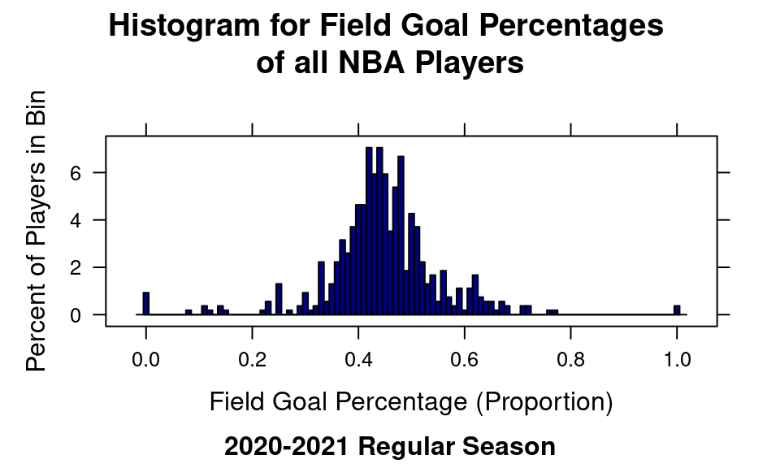

```r
histogram(~FieldGoalPercentage, data=df3, #generates a histogram of field goal percentage
          width = .01,
          main = "Histogram for Field Goal Percentages
of all NBA Players",
          sub = "2020-2021 Regular Season",
          xlab = "Field Goal Percentage (Proportion)",
          ylab = "Percent of Players in Bin",
          col = "navyblue")
```

### 2.3 Graph #2: Box and Whisker Plots

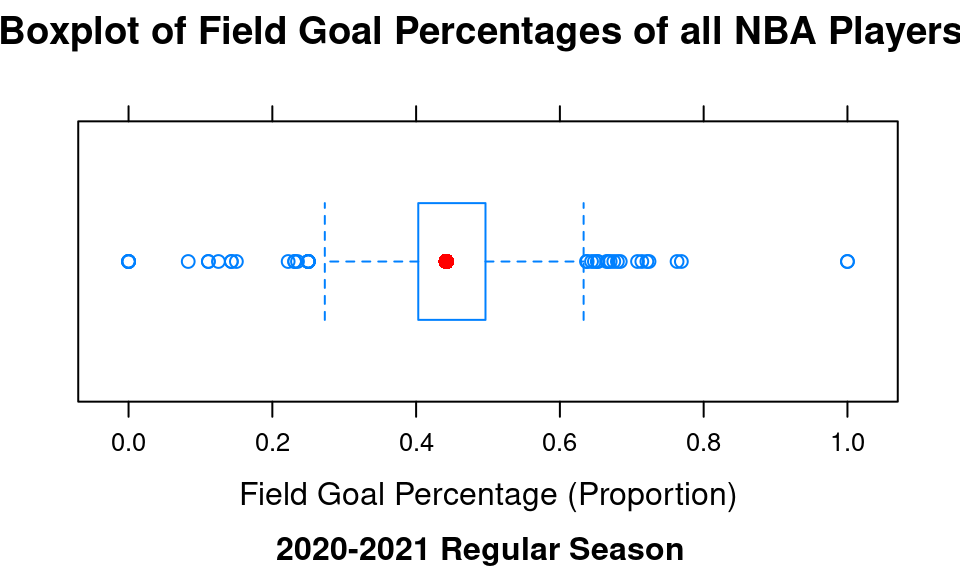

```r
bwplot(~FieldGoalPercentage, data = df3, #generates a boxplot of field goal percentage
       main = "Boxplot of Field Goal Percentages of all NBA Players",
       sub = "2020-2021 Regular Season",
       xlab = "Field Goal Percentage (Proportion)",
       col = "red")
```

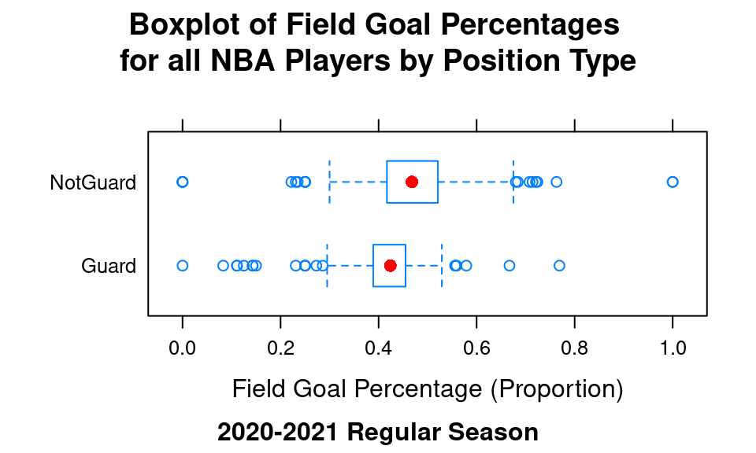

```r
bwplot(Position~FieldGoalPercentage, data = df3, #generates a boxplot of field goal percentage
       main = "Boxplot of Field Goal Percentages
for all NBA Players by Position Type",
       sub = "2020-2021 Regular Season",
       xlab = "Field Goal Percentage (Proportion)",
       col = "red")
```

### 2.4 Well-constructed paragraph - response variable

The favstats output as well as the histogram and boxplot are generated from the FieldGoalPercentage variable which contains the proportion of field goals made for each NBA player during the 2020-2021 regular season. The histogram above shows that the shape of the field goal percentage appears to be fairly symmetrical. The center of field goal percentage is around a 50th percentile (median) of 0.442 and a mean of 0.448, this further supports the claim that the data is symmetrical as difference in mean and median is less than .01. In the data field all NBA players have a field goal percentage between and including 0.000 and 1.000, there are players who either made or missed every shot they took in the regular season. It is important to note the five unusual players who missed every shot, and the two players who made every shot they took. The boxplot generated from the field goal percentage also highlights the symmetrical structure of the field goal percentage variable, while highlighting various other players who may be considered outliers based on their field goal percentage, who did not either make or miss all of their shots. The middle fifty percent (Interquartile Range) for field goal percentage falls between 0.403, and 0.497. The average distance for each player is about .107 away from the mean (standard deviation). Two additional boxplots have also been generated. These box plots split the players into position type before plotting their field goal percentages. This allows for a quick comparison between field goal percentage of guards and not guards before further analysis is conducted later. The center for players who are not guards appears to be slightly greater than the center of field goal percentage for players who are guards. The variability of guards also appears to be smaller than the variability of players who are not guards. Both boxplots appear to be symmetric and both position types have their fair share of outliers as indicated by the boxplot.

## Phase 3. Data Analysis Plan

In Phase 3 the documented procedure for how the two explanatory variables will be separately compared with the response variable is shown. As mentioned before the response variable which is going to be analyzed is each player’s field goal percentage for the 2020-2021 regular season. The two subsections below (3.1 and 3.2) are going to discuss the simulations for comparing the response variable with two explanatory variables: the player’s position (3.1) and the total number of regular season games a player played in (3.2).

### 3.1 Field Goal Percentage (Response) vs. Position

My conjecture is that players identified as guards will have a different field goal percentage than players who do not identify as guards. I believe this to be true because you could make an argument for either direction: players who are not guards typically take shots closer to the basket, thus easier to make. While guards shoot from farther away, they take those shots because they are typically better shooters.

With field goal percentage being a numeric variable and the position of a player being a binomial categorical variable, a two-mean inference procedure can be conducted as follows: The mean field goal percentage for all guards and all non-guards in the sample will be calculated. The difference between these two means is the observed test statistic.

From the 540 observational units there are 540 field goal percentages. The 540 response values will be shuffled and randomly assigned to an ‘A’ group and a ‘B’ group. The ‘A’ group will always be as large as the number of guards in the sample and the ‘B’ group will always be as large as the number of non-guards in the sample. The average field goal percentage will be calculated for each of the groups and the difference between the two groups will be calculated. Using a computer, the simulation can be repeated 999 more times for 1000 simulated test statistics.

The number of simulated test statistics which were as or more extreme as the observed test statistic will be counted. If 50 or less simulations are more extreme than the observed test statistic (p-value<0.05), this will be seen as evidence for the conjecture.

### 3.2 Field Goal Percentage (Response) vs. Regular Season Games Played

My conjecture is that there will be a direct association between a player’s field goal percentage and the number of games the player played in. I believe that this will be true because the players who have higher field goal percentages will play more games, because they can make shots at a more efficient rate.

Both field goal percentage as well as regular season games played are numeric variables. An XY plot can be created with 540 points. Each point is an observational unit from the sample and is plotted in the x direction by the number of games the player played in and is plotted in the y direction for the player’s field goal percentage for the season. From this xy plot a best fit line can be placed and the strength of the correlation between the two variables can be counted.

To test this conjecture a correlation will be computed, and if the correlation is greater than 0, it will be considered evidence to support the conjecture.

## Phase 4. Statistical Results

### 4.1 Results - Field Goal Percentage (Response) vs. Position

Before conducting the two-mean inference procedure we can state our hypotheses: let xbarGuard = the average field goal percentage for all players from the 2020-2021 season who are identified as guards let xbarNotGuard = the average field goal percentage for all players from the 2020-2021 season who are identified as non guards H0: xbarGuard = xbarNotGuard Ha: xbarGuard != (not equal to) xbarNotGuard

```r
favstats(~FieldGoalPercentage|Position, data=df3)
```

```
##   Position min      Q1 median      Q3   max      mean         sd   n missing
## 1    Guard   0 0.38900  0.424 0.45500 0.769 0.4150306 0.08561995 229       1
## 2 NotGuard   0 0.41725  0.468 0.52075 1.000 0.4718387 0.11465663 310       0
```

The favstats command shows statistics for field goal percentage broken down by position played. Both position types have at least one player who missed all their shots (minimum values of 0); however, only non guards have players who made all their shots during the season (maximum values of 1.0). The median for non guards is higher than the median for guards at .468 to .424. The middle 50% for guards falls between .389 and .455 whereas the middle 50% of field goal percentage for non guards lies between .417 and .520.

```r
# Compute the observed difference in the means between the two groups
observed <- diffmean(~FieldGoalPercentage | Position, data=df3, na.rm = T)
paste("Observed difference in the means: ", round(observed, 3 ))
```

```
## [1] "Observed difference in the means:  0.057"
```

The observed difference in average field goal percentage between the guards and non guards is .057

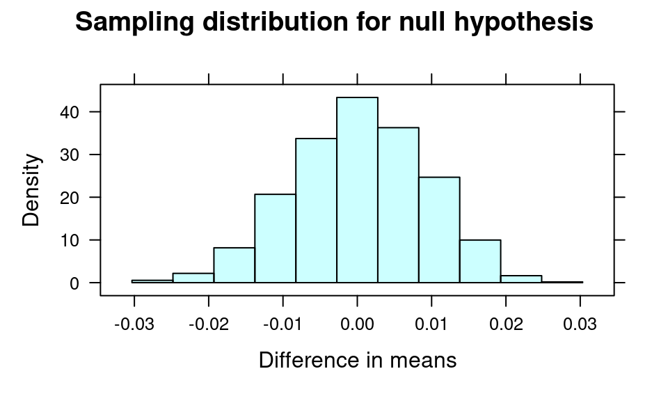

```r
set.seed(813)
trials <- 1000

# Compare the difference in means when we shuffle the Position variable - do this lots of times
null.dist <- do(trials) * diffmean(FieldGoalPercentage ~ shuffle(Position), data=df3, na.rm = T)

# Graph the histogram with the observed difference of proportions
histogram( ~ diffmean, data=null.dist,
           main = "Sampling distribution for null hypothesis",
           xlab = "Difference in means",
           groups = diffmean >= observed,
           v = observed, na.rm = T)
```

```r
# Let's compute the p-value
if (observed > 0) {
  pvalue <- prop(~ diffmean >= observed, data=null.dist)
} else {
  pvalue <- prop(~ diffmean <= observed, data=null.dist)
}
paste("The two-sided p-value is ", 2 * round(pvalue,3))
```

```
## [1] "The two-sided p-value is  0"
```

With a p-value of approximately 0, we have evidence to support our conjecture and have evidence to reject our null hypothesis. We have evidence to believe that average field goal percentage is different for guards and non-guards.

### 4.2 Results - 3.2 Field Goal Percentage (Response) vs. Regular Season Games Played

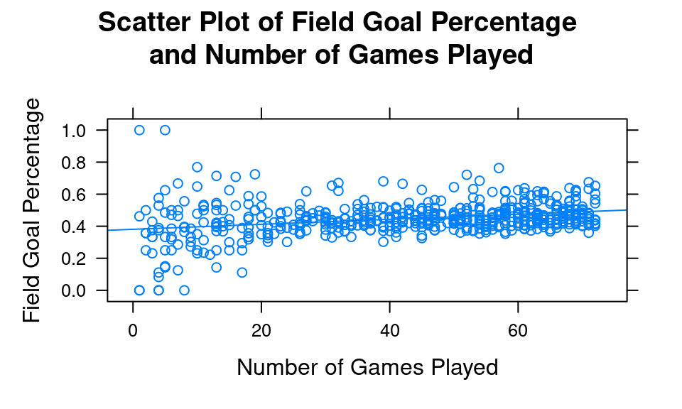

```r
xyplot(FieldGoalPercentage ~ GamesPlayed, data=df3,
       main = "Scatter Plot of Field Goal Percentage
and Number of Games Played",
       xlab = "Number of Games Played",
       ylab = "Field Goal Percentage",
       type = c("p", "r"))
```

```r
cor(FieldGoalPercentage ~ GamesPlayed, data=df3, use = "complete.obs")
```

```
## [1] 0.3017557
```

With a positive correlation, we have evidence to support our conjecture. Generally as regular season games played increases, the field goal percentage of the player increases. A player with higher than average regular season games played is expected to have a higher than average field goal percentage.

```r
(model<- lm(FieldGoalPercentage ~ GamesPlayed, data=df3))
```

```
##
## Call:
## lm(formula = FieldGoalPercentage ~ GamesPlayed, data = df3)
##
## Coefficients:
## (Intercept)  GamesPlayed
##    0.380842     0.001563
```

Predicted Field Goal Percentage = 0.380842 + 0.001563 * Number of Games Played

The model created predicts that as a player participates in one additional game played, the player’s field goal percentage is predicted to increase by about 0.0016. A player who plays in no games is predicted to have a field goal percentage of about .380, this data is extrapolated as no player in the sample played 0 games. Also it is impossible to have a field goal percentage if you do not play.

```r
predict(model, data.frame(GamesPlayed = 42))
```

```
##         1
## 0.4465024
```

The model predicts that a player who plays in 42 games will have a predicted field goal percentage of about .447.

## Conclusion

After completing the statistical procedures, both generated conjectures were found to be correct. The average field goal percentage from guards and non-guards was found to be different from one another. Generally as a player’s number of games played increased, a player’s field goal percentage increased as well.

During this project I learned a lot about the practical use of the 3s method for using statistics to solve problems. I retrieved my statistics and then ran analysis on different variables independently from each other. I ran two simulations in order to test relationships between variables. Then I used strength of evidence to determine if my conjecture could be proven or not. This method definitely made presenting my information a lot easier to implement, and hopefully made my report a lot easier to read.

Looking back, instead of doing field goal percentage, I would have analyzed free throw percentage as the response variable. There are a lot of different factors which influence if a basket is made or not besides the two analyzed explanatory variables. A free throw, when the game of basketball is stopped and the only action is the shooter shooting the shot, would have been a lot easier to find a more direct relationship.